# Oral Cancer Trends: Pakistan

Ayesha Shamsi

2025-03-05

[Link to Dataset](https://docs.google.com/spreadsheets/d/1H1wBPrzqzt7vhjLHNJI_ktnYj4qRohTM/edit?usp=drive_link&ouid=110881487042061949976&rtpof=true&sd=true)

## Motivation:

I am interested in analysing more social aspects like the types of tobacco use, difference in uses amongst people and the effects of tumor sizes on important factors like survival rates to see if I can draw new conclusions about the prevalence of diagnosis and oral cancer in Pakistan.

## Quick Summary

Amongst our population, indivicuals with smaller tumor sizes had generally better survival probabilities. The most common form of tobacco consumption was chewaable, with a higher prevelance in men than women.

## Tumor Sizes Impact on Survival

My data set was manipulated to be able to use the Kaplan Mier survival model.

Survival time was calculated by using year (assumed to be the date of diagnosis) and the date of last contact or death (assumed to be date of death) if the vital status was deceased.

The tumor sizes were also divided into less than 20, between 20-40 and above 40 based on averages. The log of tumor sizes was used for correlation analysis (both Pearsons and Spearmans) and a linear regression.

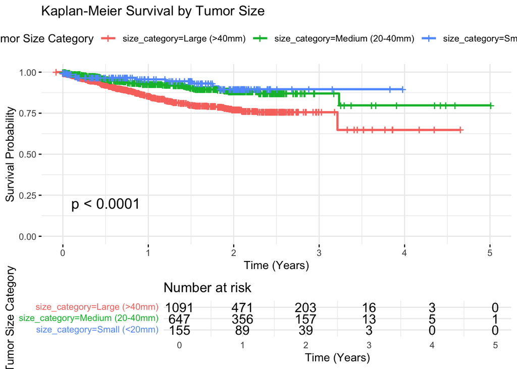

```
## Pearson Correlation: -0.1227577
```

```
## Spearman Correlation: -0.1604546
```

```
##
## Call:
## lm(formula = survival_time ~ log_tumor_size, data = df)
##
## Residuals:
##     Min      1Q  Median      3Q     Max
## -1.6034 -0.7294 -0.2051  0.7116  3.8237
##
## Coefficients:
##                Estimate Std. Error t value Pr(>|t|)
## (Intercept)     1.81829    0.12702  14.315  < 2e-16 ***
## log_tumor_size -0.18068    0.03357  -5.382 8.29e-08 ***
## ---
## Signif. codes:  0 '***' 0.001 '**' 0.01 '*' 0.05 '.' 0.1 ' ' 1
##
## Residual standard error: 0.8738 on 1893 degrees of freedom
##   (415 observations deleted due to missingness)
## Multiple R-squared:  0.01507,    Adjusted R-squared:  0.01455
## F-statistic: 28.96 on 1 and 1893 DF,  p-value: 8.295e-08
```

The chart and visuals show us that the survival rate for tumor sizes larger than 40 mm drop significantly compared to the smaller two categories after the first year since diagnosis. This makes sense as:

-Larger tumors are generally associated with later stages of diagnosis. -Smaller tumors may undergo more treatment if diagnosed sooner.

Both correlations are negative, there is smaller survival times/chances with larger tumor sizes. However, the correlation values are generally weak, with Spearman slightly higher due to 2-3 large tumor sizes in the data set.

This indicates that while there is a relationship, tumor size alone does not strongly predict survival time. Patient genetic factors, family historyand lifestyle choices (e.g., tobacco use, diet, exercise) could influence survival beyond tumor size alone.

## Most Common Tobacco use

In this case we are interested to see the disttibution of different types of Tobacco use amongst the cases. We use dypler to count these variables and add a percentage for us to analyze.

```
##    patient_history_tobacco   n  percentage
## 1  SNUFF/SMOKELESS CURRENT 785 33.98268398
## 2               NEVER USED 721 31.21212121
## 3             PREVIOUS USE 373 16.14718615
## 4      COMBINATION CURRENT 305 13.20346320
## 5 CIGARETTE SMOKER CURRENT 120  5.19480519
## 6       CIGAR/PIPE CURRENT   4  0.17316017
## 7                     NONE   2  0.08658009
```

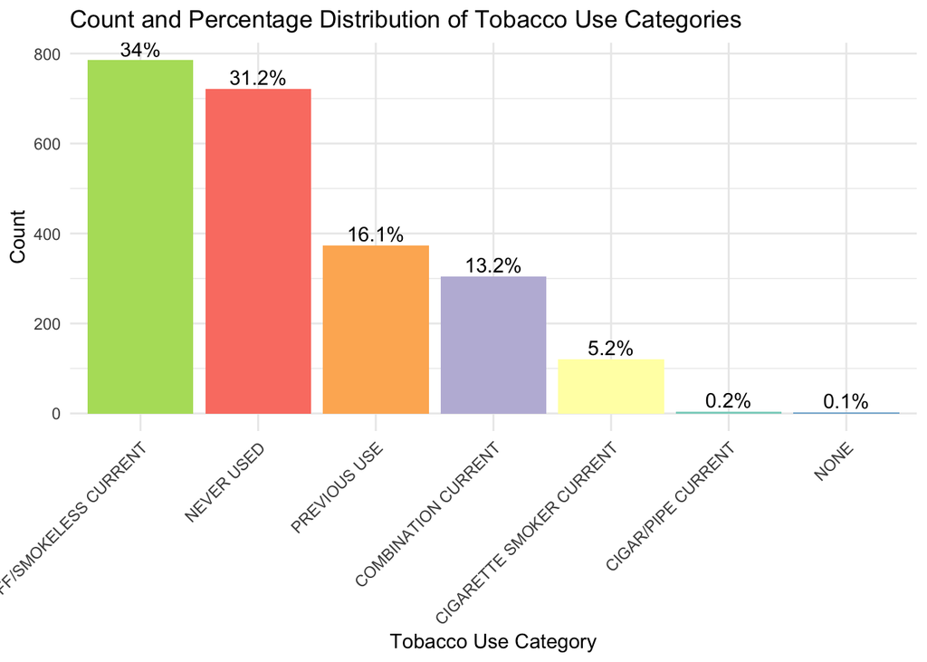

The Never used being the second most common category tells us that there is a complex interplay of several factors beyond nicotine use like age, gender, oral hygience and lifestyle.

## Chewing Tobacco use by Gender

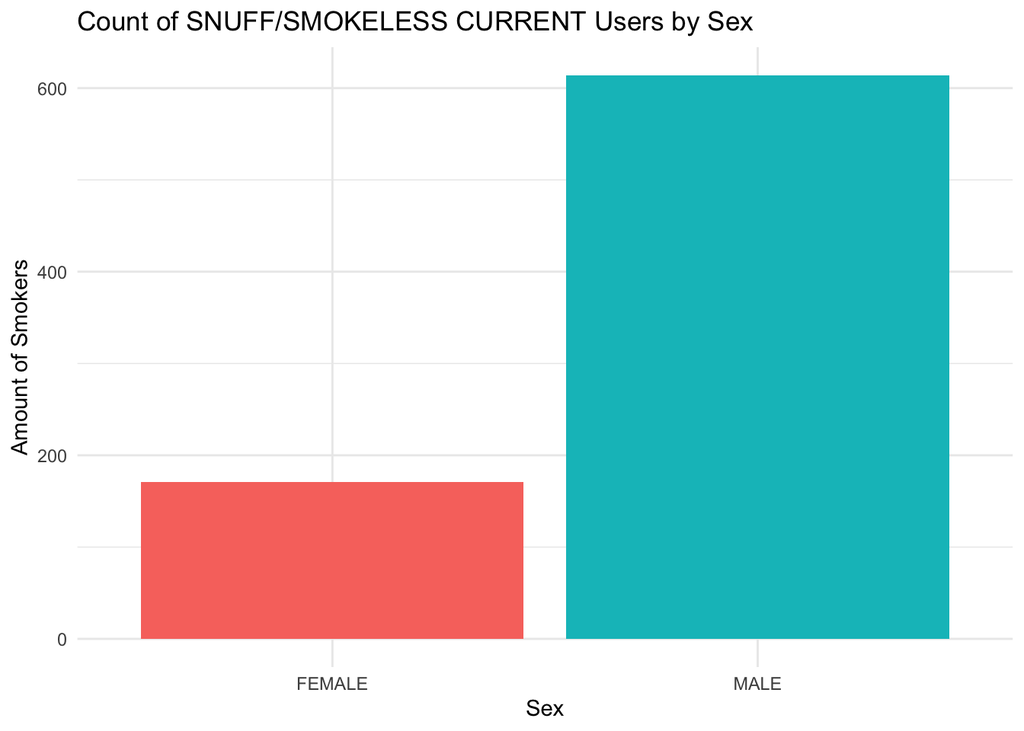

```
##
##     FEMALE MALE
##   0    401 1124
##   1    171  614
```

```
##
##  Two Sample t-test
##
## data:  snuff_user by sex
## t = -2.3814, df = 2308, p-value = 0.01733
## alternative hypothesis: true difference in means between group FEMALE and group MALE is not equal to 0
## 95 percent confidence interval:
##  -0.099066107 -0.009591059
## sample estimates:
## mean in group FEMALE   mean in group MALE
##            0.2989510            0.3532796
```

Our results found more men smoking chewable tobacco products than women. Although in this study, females had less use of chewable tobacco products amongst other populations and studies like this one [this one](https://pmc.ncbi.nlm.nih.gov/articles/PMC2778071/) done in Bangladesh, found more women used smokeless tobacco products than men. However, it is consistent than more men smoke overall among both studies and populations. Further analysis may be needed into specific smoking trends amongst men and women with more insight into demographics and local practices/prevelance.

## Conclusion:

Our analysis highlights a negative relationship between tumor size and survival time, Kaplan-Meier survival curves reinforces this trend, showing a significant drop in survival probability for tumors larger than 40 mm within the first year after diagnosis.

However, it only explains about 1.5% of this trend, and further analysis could be conducted with more factors like age, lifestyle and family history to give us a better idea about survival rates.

Additionally, our data shows that smokeless tobacco (SNUFF/SMOKELESS CURRENT) is the most common form of tobacco use among patients, with a higher prevalence among men than women. Given that tobacco use is a known risk factor for various cancers, future analysis should examine its direct impact on tumor development and survival outcomes. There should also be more education and intervention on the use of chewable tobacco products and their negative effects amongst the local population.